# Visualizing Chicago’s Changing Neighborhoods

Cory Rand

February 10, 2019

### Plot 1

Since 1970, Chicago has undergone major demographic changes. The grey box shows the last 17 years, over which the white population has increased sharply, and minority populations have begun declining or have leveled off.

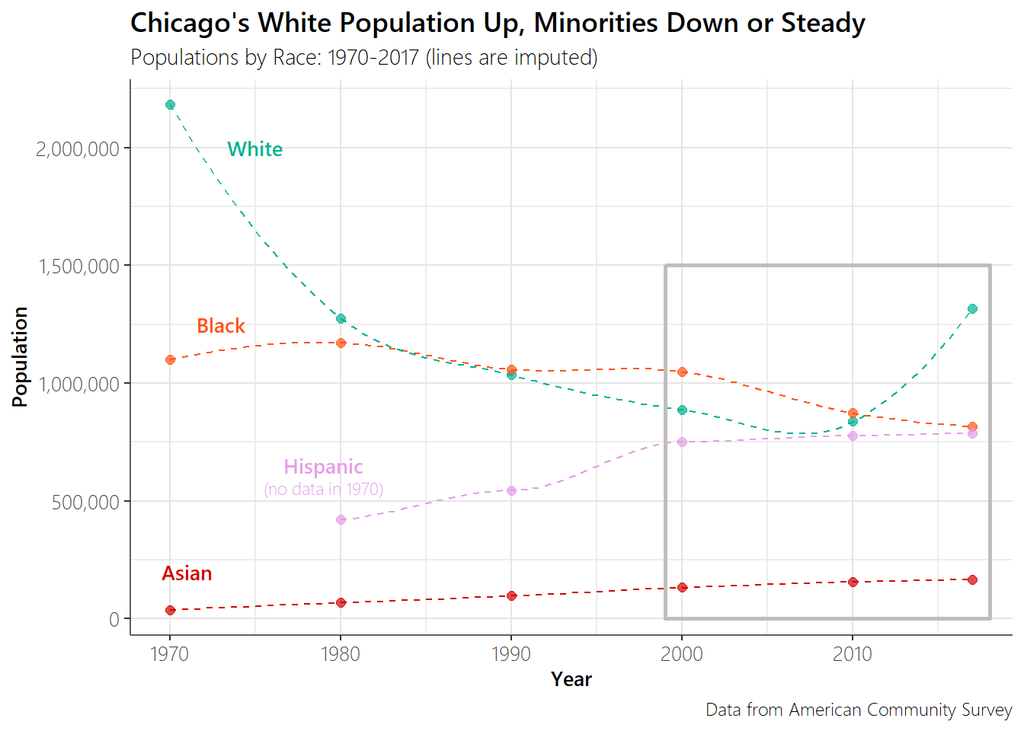

```r
demo_graph_data <- master %>%
  select(REGION, YEAR, nhwht, nhblk, asian, hisp) %>%
  distinct() %>%
  group_by(YEAR) %>%
  summarize(White = sum(nhwht, na.rm = T),
            Black = sum(nhblk, na.rm = T),
            Asian = sum(asian, na.rm = T),
            Hispanic = sum(hisp, na.rm = T)) %>%
  filter(White != 0) %>%
  gather(key = "Race", value = "Pop", -c(YEAR))

demo_graph_data$Pop[demo_graph_data$Pop == 0] <- NA

  ggplot(demo_graph_data, aes(x = YEAR, y = Pop, col = Race)) +
  scale_color_manual(values= c("#D60000", "#FF5416","#E49DE8", "#00B28F")) +
  scale_y_continuous(labels = comma) +
  geom_point(size = 2, alpha = 0.7) +
  geom_smooth(linetype = "dashed", size = 0.5, alpha = 0.5) +
  labs(
  title="Chicago's White Population Up, Minorities Down or Steady",
  subtitle="Populations by Race: 1970-2017 (lines are imputed)",
  caption="Data from American Community Survey",
  x="Year",
  y="Population"
  ) +
  geom_rect(xmin = 1999, xmax = 2018,
            ymin = 0, ymax = 1500000,
            alpha = 0, color = "grey", size = 1) +
  annotate("text", label="White", x=1975, y=1998000, size=3.5, color = "#00B28F", family="Segoe UI Semibold") +
  annotate("text", label="Black", x=1973, y=1250000, size=3.5, color = "#FF5416", family="Segoe UI Semibold") +
  annotate("text", label="Asian", x=1971, y=198000, size=3.5, color = "#D60000", family="Segoe UI Semibold") +
  annotate("text", label="Hispanic", x=1979, y=650000, size=3.5, color = "#E49DE8", family="Segoe UI Semibold") +
  annotate("text", label="(no data in 1970)", x=1979, y=555000, size=3, color = "#E49DE8", family = "Segoe UI Light") +
    theme_classic() +
  theme_custom +
      theme(legend.position="none")
```

### Plot 2

Looking at how neighborhood-level demographics changed over those 17 years emphasized above, we see that most neighborhoods are less black and more white than in 2000. The lower right quadrant shows neighborhoods that have increased their percentages of white residents and decreased their percentages of black residents. The graph also has an accompanying map showing the locations of those neighborhoods.

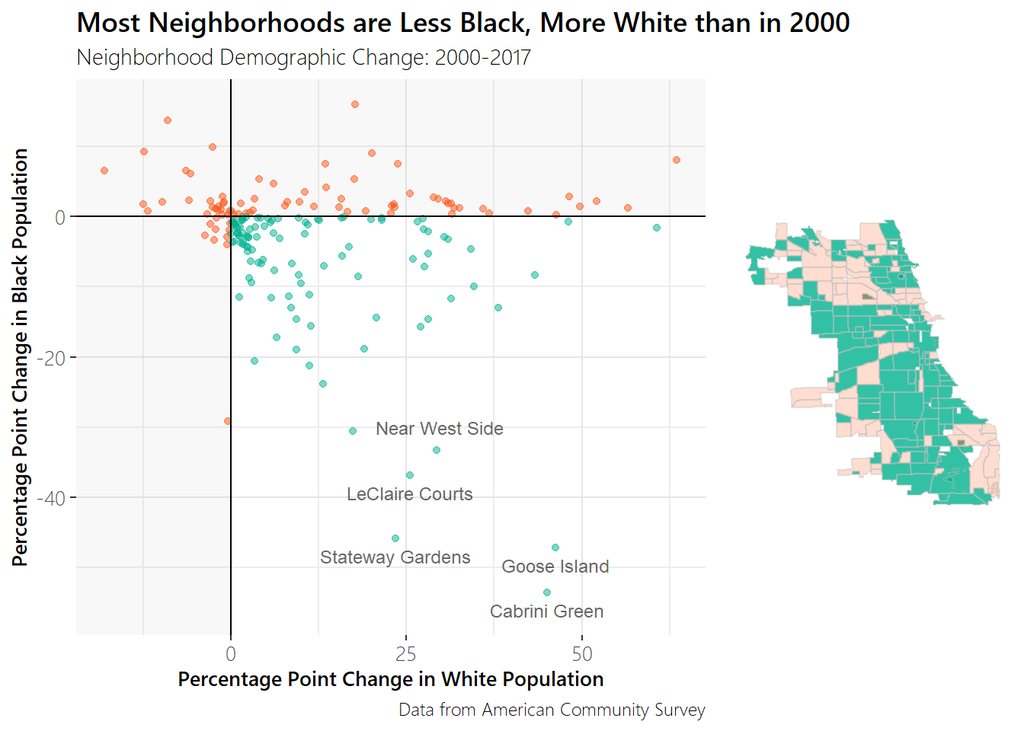

```r
plot_data <- neighborhood_master_wide %>%
    mutate(pblack_2000_2017 = (`2017_pblack` - `2000_pblack`)* 100,
           pwhite_2000_2017 = (`2017_pwhite` - `2000_pwhite`)* 100) %>%
  subset(subset = RegionID != "403159" & !is.na(pwhite_2000_2017), select=c(long, lat, group, RegionID, pwhite_2000_2017, pblack_2000_2017)) %>%
  left_join(zillow_shp@data[, c("RegionID", "Name")]) %>%
  distinct(RegionID, .keep_all = T) %>%
  mutate(highlight = pwhite_2000_2017 > 0 & pblack_2000_2017 < 0)

p1 <- plot_data %>%
ggplot(aes(x = pwhite_2000_2017, y = pblack_2000_2017, label = Name, col = highlight)) +
 annotate("rect", xmin = -Inf, xmax = 0, ymin = -Inf, ymax = Inf, fill= "grey", alpha = 0.1)  +
 annotate("rect", xmin = 0, xmax = Inf, ymin = 0, ymax = Inf, fill= "grey", alpha = 0.1)  +
  geom_jitter(alpha = 0.5) +
  geom_hline(yintercept = 0) +
  geom_vline(xintercept = 0) +
  geom_text(data = plot_data[which(plot_data$pwhite_2000_2017 > 20 & plot_data$pblack_2000_2017 < -35),],
            aes(x = pwhite_2000_2017, y = pblack_2000_2017, label = Name),
            size = 3.2,
            nudge_y = -2.5,
            family="Segoe UI Bold",
            color = "black",
            alpha = .6) +
  annotate("text", label="Near West Side", x=29.8, y=-30, alpha = .6, size=3.2, family="Segoe UI Bold") +
  scale_color_manual(values = c("#FF5416", "#00B28F")) +
       labs(x = "Percentage Point Change in White Population",
          y = "Percentage Point Change in Black Population",
          title = "Most Neighborhoods are Less Black, More White than in 2000",
          subtitle = "Neighborhood Demographic Change: 2000-2017",
          caption = "Data from American Community Survey") +
    theme_classic() +
  theme_custom +
   theme(axis.line = element_blank()) +
    theme(legend.position="none")

temp_data <- neighborhood_master_wide %>%
    mutate(pblack_2000_2017 = `2017_pblack` - `2000_pblack`,
           pwhite_2000_2017 = `2017_pwhite` - `2000_pwhite`) %>%
  subset(subset = RegionID != "403159" & !is.na(pwhite_2000_2017), select=c(long, lat, group, RegionID, pwhite_2000_2017, pblack_2000_2017)) %>%
  left_join(zillow_shp@data[, c("RegionID", "Name")]) %>%
  mutate(highlight = pwhite_2000_2017 > 0 & pblack_2000_2017 < 0)

p2 <- ggplot() +
    geom_polygon(data = temp_data[which(temp_data$highlight > 0),],
                 aes(x = long, y = lat, group = group), fill = "#00B28F", alpha = .8) +
    geom_path(data = temp_data[which(temp_data$highlight > 0),],
                 aes(x = long, y = lat, group = group), col = "grey", alpha = .4) +
    geom_polygon(data = temp_data[which(temp_data$highlight == 0),],
                 aes(x = long, y = lat, group = group), fill = "#FF5416", alpha = .2) +
    geom_path(data = temp_data[which(temp_data$highlight == 0),],
                 aes(x = long, y = lat, group = group), col = "grey", alpha = .4) +
    coord_equal() +
    theme_minimal() +
    theme(axis.line = element_blank(),
    axis.text.x = element_blank(),
    axis.text.y = element_blank(),
    axis.ticks = element_blank(),
    axis.title.x = element_blank(),
    axis.title.y = element_blank(),
    panel.grid.major = element_blank(),
    panel.grid.minor = element_blank()) +
    theme(legend.position="none")

rm(temp_data)
grid.newpage()
page.layout <- grid.layout(nrow = 1, ncol = 2, widths=c(.7, .3))
pushViewport(viewport(layout = page.layout))
print(p1, vp=viewport(layout.pos.row = 1, layout.pos.col = 1))
print(p2, vp=viewport(layout.pos.row = 1, layout.pos.col = 2))
```

### Plot 3

This next plot shows how the spatial distribution of the white population in Chicago has changed since 1970. From 1970-2000, many census tracts lost percentage shares of white residents. From 2000-2017, however, many of these same tracts experienced an influx of white residents.

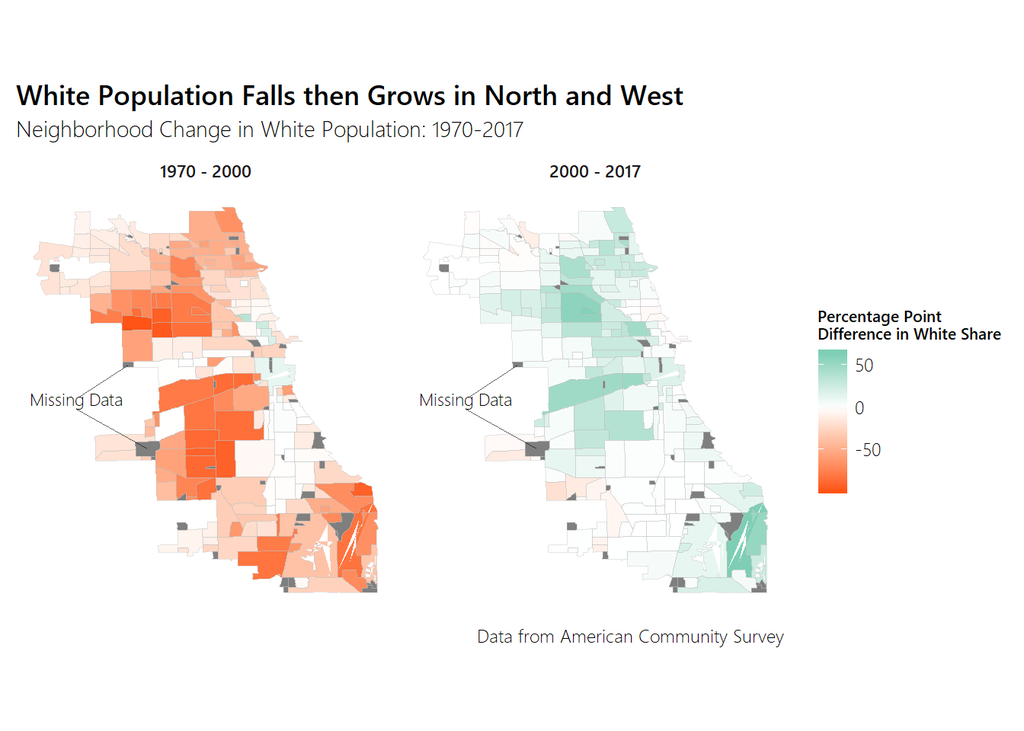

```r
neighborhood_master_wide %>%
    mutate(pwhite_1970_2000 = (`2000_pwhite` - `1970_pwhite`) * 100,
           pwhite_2000_2017 = (`2017_pwhite` - `2000_pwhite`)* 100) %>%
    subset(subset = RegionID != "403159", select=c(long, lat, group, RegionID, pwhite_1970_2000, pwhite_2000_2017)) %>%
  gather(key = "YEAR", value = "pwhite", -c(RegionID, long, lat, group)) %>%
  mutate(YEAR = gsub("pwhite_1970_2000", "1970 - 2000", YEAR),
         YEAR = gsub("pwhite_2000_2017", "2000 - 2017", YEAR)) %>%

    ggplot(aes(x = long, y = lat)) +
    geom_polygon(aes(fill = pwhite, group = RegionID)) +
    geom_path(aes(group = group),
                  color = "grey", size = 0.01, alpha = 0.4) +
    coord_equal() +
    facet_wrap(~YEAR) +
    scale_fill_gradient2(low = "#FF5416", high = "#00B28F") +
    annotate("text", label = "Missing Data",
             x = -87.82, y = 41.835,
             size = 3,
             family="Segoe UI Light") +
    annotate("segment",
             x = -87.8159, xend = -87.76916, y = 41.8375, yend = 41.86824, colour = "black", size=0.3, alpha=.6) +
      annotate("segment",
             x = -87.82, xend = -87.75072, y = 41.8245, yend = 41.78588, colour = "black", size=0.3, alpha=.6) +
     labs(x = NULL,
          y = NULL,
          title = "White Population Falls then Grows in North and West",
          subtitle = "Neighborhood Change in White Population: 1970-2017",
          caption = "Data from American Community Survey",
          fill = "Percentage Point \nDifference in White Share") +
      theme_minimal() +
  theme_custom +
      theme(axis.line = element_blank(),
      axis.text.x = element_blank(),
      axis.text.y = element_blank(),
      axis.ticks = element_blank(),
      axis.title.x = element_blank(),
      axis.title.y = element_blank(),
      panel.grid.major = element_blank(),
      panel.grid.minor = element_blank(),
      legend.key.size = unit(0.5, "cm"),
      legend.title = element_text(size = 8),
      strip.text.x = element_text(family="Segoe UI Semibold"))
```

### Plot 4

This plot shows the correlations of Home Value, Race, and Population in Chicago’s neighborhoods at a single recent snapshot in time. Whiter neighborhoods have less population and more expensive homes.

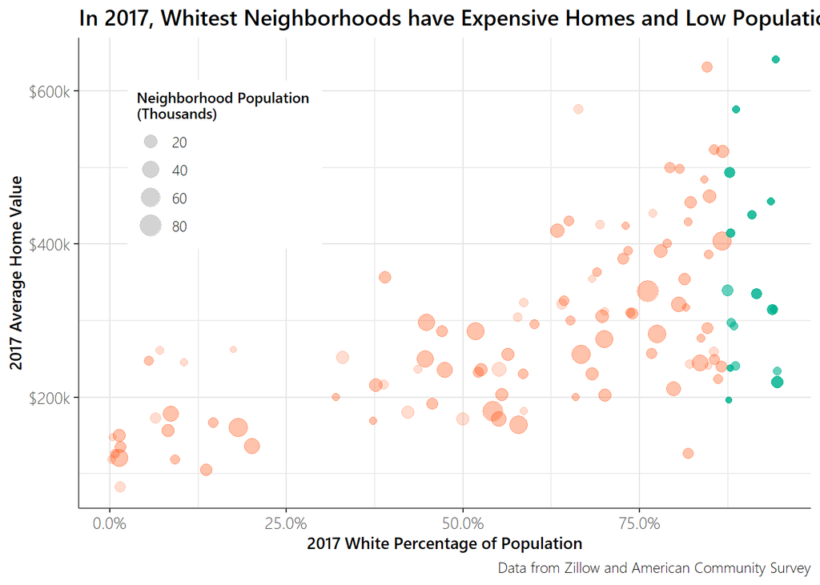

```r
plot_data <- master %>%
  filter(YEAR == 2017, pop > 0 & pop < 2000000) %>%
  mutate(pop_bins = cut(pop, breaks = seq(0, 99000, 33000), include.lowest = TRUE),
         pop = pop / 1000)

ggplot() +
  geom_point(data = plot_data[which(plot_data$pwhite < .87),],
             aes(x = pwhite, y = mean_hvi, size = pop),
             alpha = .2,
             col = "#FF5416") +
  geom_point(data = plot_data[which(plot_data$pwhite > .87),],
             aes(x = pwhite, y = mean_hvi, size = pop),
             col = "#00B28F",
             alpha = .6) +
  labs(
      title="In 2017, Whitest Neighborhoods have Expensive Homes and Low Populations",
      #subtitle="Average Home Values and Demographic Data in 2017 ",
      caption="Data from Zillow and American Community Survey",
      x="2017 White Percentage of Population",
      y="2017 Average Home Value",
      size = "Neighborhood Population \n(Thousands)"
      ) +
  theme_classic() +
  #scale_color_manual(labels = c("0-33k", "33-66k", "66-99k"), values = c("#00B28F", "#FF5416","#D60000")) +
  scale_y_continuous(labels = c("0", "$200k", "$400k", "$600k")) +
  scale_x_continuous(labels = scales::percent) +
  guides(size = guide_legend(override.aes = list(col = "grey"))) +
  theme(legend.position = c(.2, .73)) +
  theme_custom
```

### Plot 5

This next plot shows how neighborhoods have become more or less expensive relative to other neighborhoods over time. The 4 highlighted districts have experienced the most change, with blue being a rise in home value ranking, and orange being a fall.

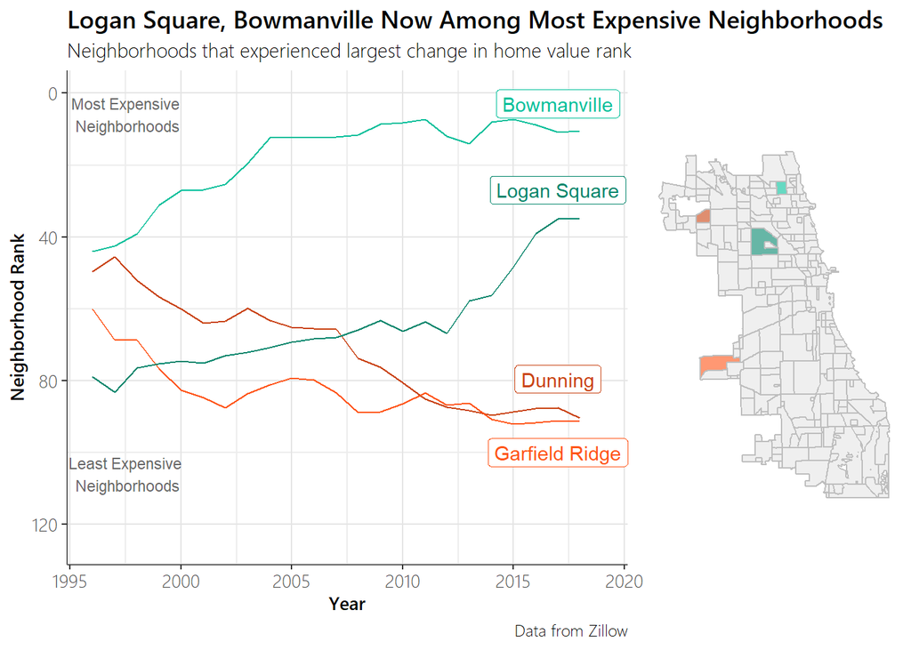

```r
master_wide_filt <- master_wide[which(!is.na(master_wide$change_rank)),]
up_neigh <- master_wide_filt$REGION[order(master_wide_filt$change_rank, decreasing = T)] %>% head(2)
down_neigh <- master_wide_filt$REGION[order(master_wide_filt$change_rank, decreasing = T)] %>% tail(2)
changing_neigh <- append(up_neigh, down_neigh)
losing_neigh <- master_wide_filt$REGION[which(master_wide_filt$change_rank < 0)]
rm(master_wide_filt)

plot_data <- master %>%
                filter(REGION %in% changing_neigh, YEAR > 1995)


p1 <- ggplot(data = plot_data, aes(x = YEAR, y = mean_rank,
                             col = factor(REGION))) +
  geom_line(aes(label = RegionName)) +
          labs(
          title="Logan Square, Bowmanville Now Among Most Expensive Neighborhoods",
          subtitle="Neighborhoods that experienced largest change in home value rank",
          caption="Data from Zillow",
          x="Year",
          y="Neighborhood Rank",
          col = NULL
          ) +
  geom_label(data = plot_data[plot_data$YEAR == 2017 &
                                plot_data$RegionName != "Garfield Ridge",],
             aes(x = YEAR, y = mean_rank,
                 col = factor(REGION),
                 label = RegionName),
             position = position_nudge(y = 8)) +
          theme_classic() +
  guides(col = FALSE) +
   scale_color_manual(values = c("#C94211", "#FF5416", "#00856B", "#00BF9A")) +
          scale_y_reverse(limits = c(125,0)) +
  annotate("label", label="Garfield Ridge", x=2017, y=100, col = "#FF5416", family="Segoe UI Bold") +
   annotate("text", label="Most Expensive \nNeighborhoods",
            x=1997.6, y=5.8, alpha = .6, family="Segoe UI Bold", size = 3) +
 annotate("text", label="Least Expensive \nNeighborhoods",
          x=1997.6, y=106, alpha = .6, family="Segoe UI Bold", size = 3) +
            theme_custom

p2 <- ggplot() +
    geom_sf(data = zillow_shp[!(zillow_shp$RegionID %in% changing_neigh) & zillow_shp$RegionID != "403159",],
            col = "grey", alpha = .6) +
    geom_sf(data = zillow_shp[zillow_shp$RegionID %in% changing_neigh,],
            aes(fill = factor(RegionID)),
            col = "grey", alpha = .6) +
    scale_fill_manual(values = c("#C94211", "#FF5416", "#00856B", "#00BF9A")) +
    theme_minimal() +
    guides(fill = FALSE) +
    coord_sf(datum=NA) +
    theme(axis.line = element_blank(),
    axis.text.x = element_blank(),
    axis.text.y = element_blank(),
    axis.ticks = element_blank(),
    axis.title.x = element_blank(),
    axis.title.y = element_blank(),
    panel.grid.major = element_blank(),
    panel.grid.minor = element_blank())

rm(plot_data)

grid.newpage()
page.layout <- grid.layout(nrow = 1, ncol = 2, widths=c(.7, .3))
pushViewport(viewport(layout = page.layout))
print(p1, vp=viewport(layout.pos.row = 1, layout.pos.col = 1))
print(p2, vp=viewport(layout.pos.row = 1, layout.pos.col = 2))
```

### Plot 6

This next plot is a directed scatter related to the plot above, showing changes in two variables - Cumulative Demolition and Construction Permits - of the 4 neighborhoods that have undergone the largest changes in home value rank. The cumulative numbers are scaled to the number of houses in each neighborhood in 2010. We see that the neighborhoods that experienced the most increase in value also have the most cumulative demolition and building permits.

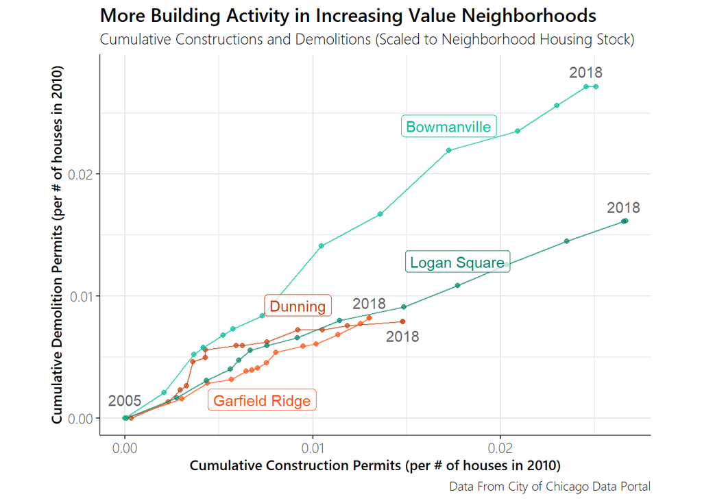

```r
plot_data <- master %>%
  subset(subset = REGION %in% changing_neigh, select = c(PERMIT_TYPE, REGION, YEAR, permits_cs, RegionName)) %>%
  distinct() %>%
  spread(key = "PERMIT_TYPE", value = "permits_cs") %>% filter(YEAR > 2004)
names(plot_data)[4:5] <- c("construction", "demolition")
#lag to replace NAs with values before it
plot_data %<>% group_by(REGION) %>%
              mutate(LAG_cons = dplyr::lag(construction,
                                           n = 1,
                                           order_by = YEAR),
                     LAG_des = dplyr::lag(demolition,
                                          n = 1,
                                          order_by = YEAR)) %>%
  left_join(master_wide[, c('REGION', '2010_hu')], by = "REGION")

plot_data$construction[which(is.na(plot_data$construction))] <- plot_data$LAG_cons[which(is.na(plot_data$construction))]
plot_data$construction[which(is.na(plot_data$construction))] <- 0
plot_data$demolition[which(is.na(plot_data$demolition))] <- plot_data$LAG_des[which(is.na(plot_data$demolition))]
plot_data$demolition[which(is.na(plot_data$demolition))] <- 0

plot_data1 <- plot_data %>%
                filter(REGION %in% changing_neigh) %>%
                mutate(construction = construction / `2010_hu`,
                      demolition = demolition / `2010_hu`)

plot_data1[order(plot_data1$REGION, plot_data1$YEAR),] %>%
  ggplot(aes(x = construction, y = demolition, group = REGION, col = factor(REGION))) +
  geom_point(alpha = 0.7) +
  geom_path(alpha = 0.7) +
  labs(x = "Cumulative Construction Permits (per # of houses in 2010)",
         y = "Cumulative Demolition Permits (per # of houses in 2010)",
         title = "More Building Activity in Increasing Value Neighborhoods",
         subtitle = "Cumulative Constructions and Demolitions (Scaled to Neighborhood Housing Stock)",
         caption = "Data From City of Chicago Data Portal") +
  scale_color_manual(values = c("#C94211", "#FF5416", "#00856B", "#00BF9A")) +
  geom_label(data = plot_data1[which(plot_data1$YEAR == 2015 & plot_data1$RegionName != "Garfield Ridge"),],
             aes(x = construction,
                 y = demolition,
                 col = factor(REGION),
                 label = RegionName),
                 nudge_y = 0.002,
                 family = "Segoe UI Bold",
                 alpha = 0.7) +
  geom_text(data = plot_data1[which(plot_data1$YEAR == 2018 & plot_data1$RegionName != "Dunning"),],
            aes(x = construction,
                y = demolition,
                label = YEAR),
            col = "black",
            nudge_y = .0012,
            alpha = .6) +
  coord_fixed(ratio = .65) +
  annotate("label", label="Garfield Ridge", x=.0073, y=.0015, alpha = .6, family="Segoe UI Bold", col = "#FF5416") +
  annotate("text", label="2018", x=.0148, y=.00674, alpha = .6, family="Segoe UI Bold") +
    annotate("text", label="2005", x=0, y=.0015, alpha = .6, family="Segoe UI Bold") +
  theme_classic() +
  theme(legend.position = "none",
        plot.title = element_text(size = 2),
        plot.subtitle = element_text(size = 1.5)) +
  theme_custom
```

### Plot 7

The plot below shows building permits for new residential construction in Chicago, 2006-2018. I chose to not have a polygon for the city because the outline is mostly clear from the points of the permits. We see areas of dense and less dense permit activity, and that permits in the south and west of the city are primarily demolition. In addition, the the North and East contain most of the city’s new construction permits, but those areas also have many demolition permits as well, showing some churn in the housing stock there.

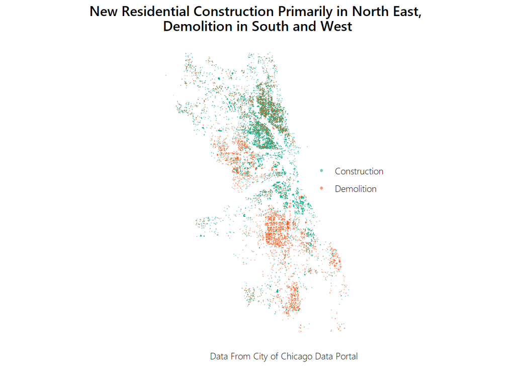

```r
permits_filt <- st_join(permits_filt, zillow_shp %>% select, join = st_within)

permits_res <- permits_filt %>%
  filter(YEAR > 2005, YEAR < 2019, RESIDENTIAL == 1,
         SFR==1 | MULTI ==1,
         BUILD ==1 | WRECK ==1,
         REGION != "403159")

mat <- list(matrix(c(-87, 41,
                     -87.86, 41,
                     -87.86, 43,
                     -87, 43,
                     -87, 41
                     ),
              ncol = 2,
              byrow = TRUE))
box <- st_polygon(mat)
box <- st_geometry(box)
box <- st_set_crs(box, st_crs(chicago_border))
chicago_crop <- st_intersection(chicago_border, box)
permits_res <- st_intersection(permits_res, chicago_border)

# mat <- list(matrix(c(-87.62, 41.89,
#                      -87.72, 41.89,
#                      -87.72, 41.965,
#                      -87.62, 41.965,
#                      -87.62, 41.89
#                      ),
#               ncol = 2,
#               byrow = TRUE))
# box <- st_polygon(mat)
# box <- st_geometry(box)
# box <- st_set_crs(box, st_crs(chicago_border))
# chicago_super_crop <- st_intersection(chicago_border, box)
# permits_super_res <- st_intersection(permits_res, chicago_super_crop)
# permits_super_res <- st_intersection(permits_res, chicago_super_crop)
#
#
# ggplot() +
#     geom_sf(data = chicago_super_crop,
#             fill = "white") +
#   geom_point(data = permits_super_res,
#            aes(x = LONGITUDE, y = LATITUDE, col = WRECK),
#            alpha =.8,
#            size = 0.1)

# mat <- list(matrix(c(-87, 41.66,
#                      -88, 41.66,
#                      -88, 43,
#                      -87, 43,
#                      -87, 41.66
#                      ),
#               ncol = 2,
#               byrow = TRUE))
# box <- st_polygon(mat)
# box <- st_geometry(box)
# box <- st_set_crs(box, st_crs(chicago_border))
# chicago_crop <- st_intersection(chicago_border, box)
# permits_super_res <- st_intersection(permits_res, chicago_crop)

ggplot() +
    geom_point(data = permits_res,
               aes(x = LONGITUDE, y = LATITUDE, col = WRECK),
               size = 1.5,
               alpha =.5,
               shape = ".") +
    scale_color_manual(values = c("#00B28F","#FF5416"),
                       labels = c("Construction", "Demolition")) +
  theme_classic() +
  coord_sf(datum=NA) +
  labs(x = NULL,
        y = NULL,
        title = "New Residential Construction Primarily in North East, \nDemolition in South and West",
        #subtitle = "Building Permits for Residential Construction and Demolition: 2006 - 2018",
        caption = "Data From City of Chicago Data Portal",
        col = NULL) +
    theme_custom +
    theme(axis.line = element_blank(),
    axis.text.x = element_blank(),
    axis.text.y = element_blank(),
    axis.ticks = element_blank(),
    axis.title.x = element_blank(),
    axis.title.y = element_blank(),
    panel.grid.major = element_blank(),
    panel.grid.minor = element_blank(),
    plot.title = element_text(hjust = .5),
    legend.position = c(.95, .55))  +
    guides(color = guide_legend(override.aes = list(size = 1, shape = 16, alpha = .6)))
```

### Plot 8

The diverging bar plot below shows timeseries data for demolition and building permits in Chicago for each year, split into multi family vs single family. Both demolition and construction permits drop sharply during the recession, and although demolition numbers soon increase above pre-recession levels, construction does not. We also see that fewer multifamily homes relative to single family homes are demolished vs constructed.

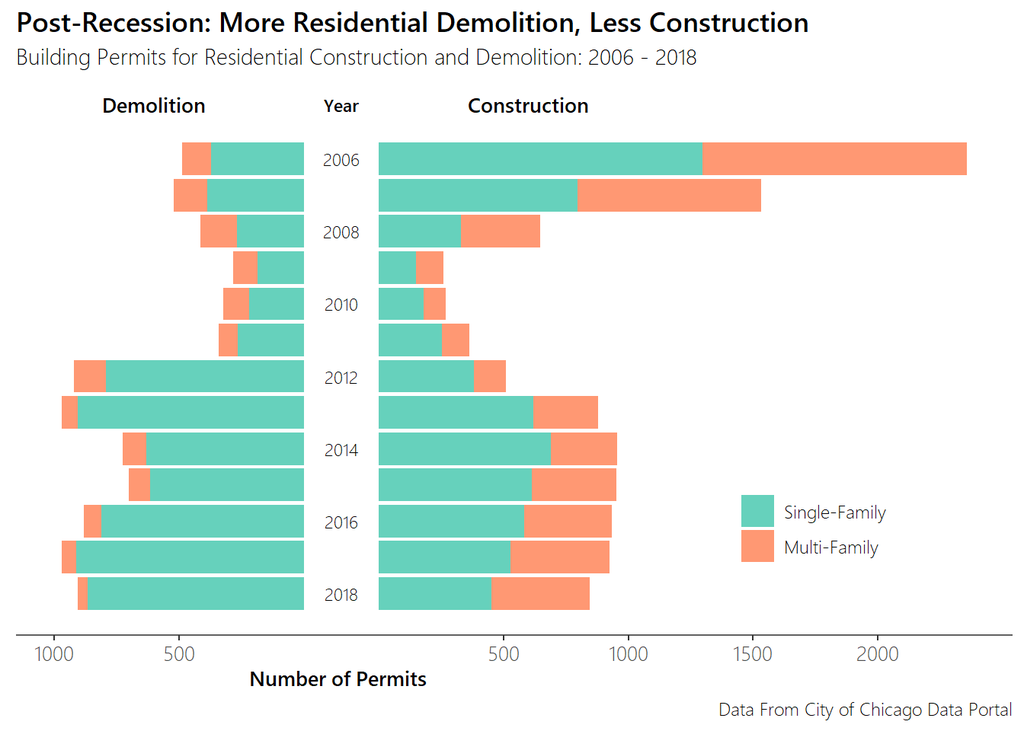

```r
YEAR <- rep(seq(2006, 2018), 2)
SFR <- rep(NA, 26)
BUILD <- c(rep(TRUE, 13), rep(FALSE, 13))
count <- rep(150, 26)
temp <- data.frame(YEAR, SFR, BUILD, count)

test<- permits_res %>%
  group_by(YEAR, SFR, BUILD) %>%
  summarize(count = n()) %>%
  bind_rows(temp) %>%
 mutate(count = ifelse(BUILD ==1, count, -count))

test$geometry <- NULL

 ggplot(test, aes(x=YEAR, y=count, fill=SFR)) +
  geom_bar(stat="identity", alpha = 0.6) +
  coord_flip() +
  scale_x_reverse() +
  theme_classic() +
  scale_fill_manual(breaks = c("TRUE", "FALSE", "NA"),
                    values = c("#FF5416", "#00B28F"),
                    labels = c("Single-Family", "Multi-Family", "")) +
  #scale_x_continuous(breaks = c(2006:2018)) +
  scale_y_continuous(breaks = c(-1150, -650, 650, 1150, 1650, 2150),
                     labels = c("1000", "500", "500", "1000",
                                "1500", "2000")) +
    labs(y = "Number of Permits",
        title = "Post-Recession: More Residential Demolition, Less Construction",
        subtitle = "Building Permits for Residential Construction and Demolition: 2006 - 2018",
        caption = "Data From City of Chicago Data Portal",
        fill = NULL) +
     annotate("text", label="Demolition", x=2004.5, y=-750, size=3.5, family="Segoe UI Semibold") +
     annotate("text", label="Construction", x=2004.5, y=750, size=3.5, family="Segoe UI Semibold") +
     annotate("text", label="Year", x=2004.5, y=0, size=3, family="Segoe UI Semibold") +
        annotate("text", label="2006", x=2006, y=0, size=3, family="Segoe UI Light") +
        annotate("text", label="2008", x=2008, y=0, size=3, family="Segoe UI Light") +
        annotate("text", label="2010", x=2010, y=0, size=3, family="Segoe UI Light") +
        annotate("text", label="2012", x=2012, y=0, size=3, family="Segoe UI Light") +
        annotate("text", label="2014", x=2014, y=0, size=3, family="Segoe UI Light") +
        annotate("text", label="2016", x=2016, y=0, size=3, family="Segoe UI Light") +
        annotate("text", label="2018", x=2018, y=0, size=3, family="Segoe UI Light") +
       theme_custom +
    theme(axis.line.y = element_blank(),
          axis.ticks.y = element_blank(),
          axis.text.y = element_blank(),
          axis.title.y = element_blank(),
          axis.title.x = element_text(hjust = 0.285),
          panel.grid.major = element_blank(),
          panel.grid.minor = element_blank(),
          legend.position = c(.8, .2))
```